# Evaluación curso R

Marta Sala Climent

## Entrega

- Recuerda completar tu **nombre en el apartado author**.
- Además del código, no olvides completar las respuestas a las preguntas indicadas en negrita.
- Si tienes dudas/dificultades, **puedes contactar con los profesores**.
- Deadline: **viernes 10 de junio, 23:59**.
- Puedes realizar la entrega en el mail: **constantino.garciama@ceu.es**.
- La entrega consistirá en este fichero rellenado y el fichero que se genera al hacer `Knit` (un fichero `Rmd` y un fichero `html`).

## Apuestas de adolescentes en UK

El conjunto de datos `teengamb.csv` contiene datos sobre las tasas de juego entre los adolescentes en Gran Bretaña, su género y estatus socioeconómico. Una pregunta que nos puede interesar es cómo se relacionan el género y los ingresos con cuánto juega una persona (céntrate solo en las variables `income`, `sex` y `gamble`)… Sigue los siguientes pasos para crear un ANCOVA…

### 1) Carga y visualiza los datos…

…para valorar si el modelo debe incluir interacciones. Escribe claramente tus conclusiones

```r
df <- read.csv("teengamb.csv")
summary(df)
```

```
##      sex                status          income           verbal
##  Length:47          Min.   :18.00   Min.   : 0.600   Min.   : 1.00
##  Class :character   1st Qu.:28.00   1st Qu.: 2.000   1st Qu.: 6.00
##  Mode  :character   Median :43.00   Median : 3.250   Median : 7.00
##                     Mean   :45.23   Mean   : 4.642   Mean   : 6.66
##                     3rd Qu.:61.50   3rd Qu.: 6.210   3rd Qu.: 8.00
##                     Max.   :75.00   Max.   :15.000   Max.   :10.00
##      gamble
##  Min.   :-33.5960
##  1st Qu.: -0.8695
##  Median : 17.7230
##  Mean   : 21.4473
##  3rd Qu.: 35.0519
##  Max.   : 88.4473
```

```r
library(psych)
descriptives <- describe(df)
print(descriptives)
```

```
##        vars  n  mean    sd median trimmed   mad   min   max  range  skew
## sex*      1 47  1.60  0.50   2.00    1.62  0.00   1.0  2.00   1.00 -0.38
## status    2 47 45.23 17.26  43.00   45.28 22.24  18.0 75.00  57.00  0.10
## income    3 47  4.64  3.55   3.25    4.14  2.45   0.6 15.00  14.40  1.33
## verbal    4 47  6.66  1.86   7.00    6.79  1.48   1.0 10.00   9.00 -0.79
## gamble    5 47 21.45 28.98  17.72   19.86 26.62 -33.6 88.45 122.04  0.47
##        kurtosis   se
## sex*      -1.90 0.07
## status    -1.31 2.52
## income     1.10 0.52
## verbal     0.69 0.27
## gamble    -0.40 4.23
```

```r
regresion <- lm(gamble ~ income, data = df)
summary(regresion)
```

```
##
## Call:
## lm(formula = gamble ~ income, data = df)
##
## Residuals:
##     Min      1Q  Median      3Q     Max
## -45.853 -17.170   1.459  16.426  57.591
##
## Coefficients:
##             Estimate Std. Error t value Pr(>|t|)
## (Intercept)    2.344      6.116   0.383 0.703362
## income         4.115      1.050   3.918 0.000301 ***
## ---
## Signif. codes:  0 '***' 0.001 '**' 0.01 '*' 0.05 '.' 0.1 ' ' 1
##
## Residual standard error: 25.3 on 45 degrees of freedom
## Multiple R-squared:  0.2543, Adjusted R-squared:  0.2378
## F-statistic: 15.35 on 1 and 45 DF,  p-value: 0.0003011
```

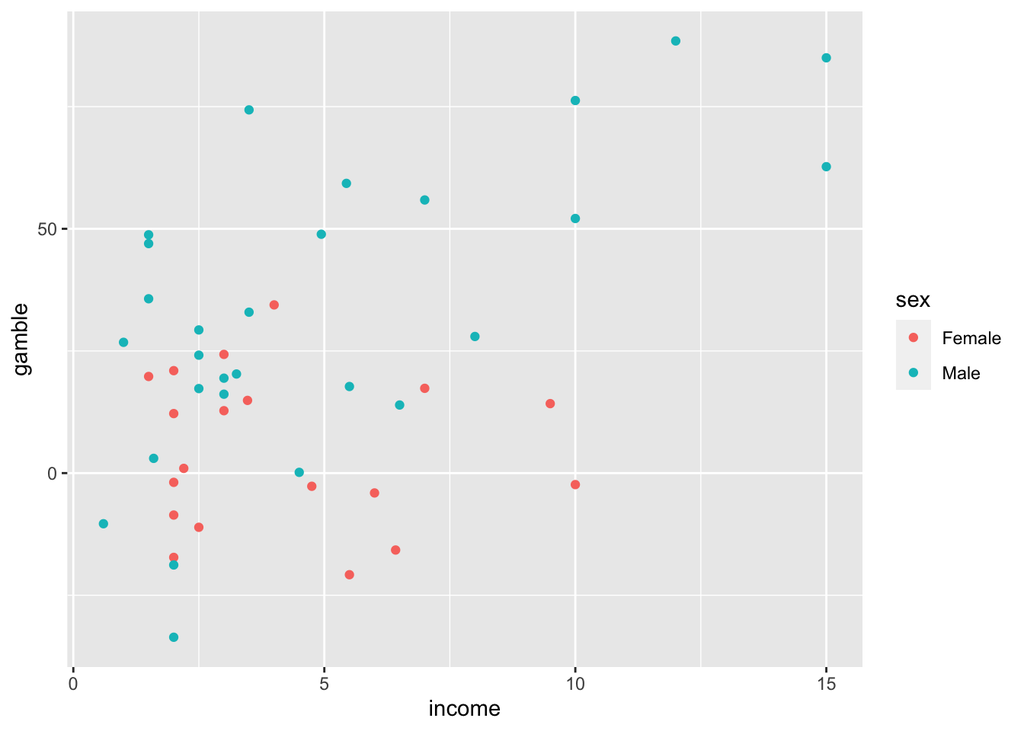

```r
library(ggplot2)
ggplot(df, aes(x = income, y = gamble)) + geom_point(aes(color = sex))
```

```r
      theme_classic()
```

[output not shown]

[output cut: 356 more lines]

[output not shown]

```r
modelo_simple <- lm(data = df,formula = status ~ sex)
modelo_simple
```

```
##
## Call:
## lm(formula = status ~ sex, data = df)
##
## Coefficients:
## (Intercept)      sexMale
##       35.26        16.74
```

```r
summary(modelo_simple)
```

```
##
## Call:
## lm(formula = status ~ sex, data = df)
##
## Residuals:
##     Min      1Q  Median      3Q     Max
## -34.000  -8.632  -1.000  10.000  29.737
##
## Coefficients:
##             Estimate Std. Error t value Pr(>|t|)
## (Intercept)   35.263      3.511   10.04 4.52e-13 ***
## sexMale       16.737      4.548    3.68 0.000622 ***
## ---
## Signif. codes:  0 '***' 0.001 '**' 0.01 '*' 0.05 '.' 0.1 ' ' 1
##
## Residual standard error: 15.3 on 45 degrees of freedom
## Multiple R-squared:  0.2313, Adjusted R-squared:  0.2142
## F-statistic: 13.54 on 1 and 45 DF,  p-value: 0.0006218
```